# R Notebook

```r
library(tidyverse)
library(tidyr)
library(DBI)
library(odbc)
```

```r
con <- dbConnect(odbc::odbc(), "akfin", UID="jwatson", PWD= rstudioapi::askForPassword("Enter AKFIN Password"))

dbFetch(dbSendQuery(con,"SELECT a.psc_fishery_code,
                                                a.year,
                                                a.el_report_id,
                                                a.trip_target_date,
                                                r.landing_date,
                                                r.port_code,
                                                a.processing_sector,
                                                a.catcher_vessel_id,
                                                a.catch_report_type_code,
                                                a.data_source_type_code,
                                                a.management_program_code,
                                                a.agency_gear_code,
                                                a.adfg_stat_area_code,
                                                a.reporting_area_code,
                                                a.pscnq_estimate,
                                                a.species_count,
                                                a.rate_precedence,
                                                a.rate,
                                                a.retained_gf_basis_weight AS RETAINED_GF_WEIGHT,
                                                a.total_gf_basis_weight,
                                                a.rate*a.total_gf_basis_weight as manual_CALC_example,
                                                a.trip_target_code,
                                                a.species_group_code,
                                                a.fmp_sub_area_code

                                                FROM akr.v_cas_txn_primary_psc a
                                                LEFT JOIN akr.V_ELLR_REPORT r
                                                on r.report_id=a.el_report_id

                                                where a.species_group_code='CHNK'
                                                and a.FMP_SUB_AREA_CODE in ('BS','GOA','AI')
                                                and a.agency_gear_code in ('NPT','PTR')")) %>%
  rename_all(tolower) %>%
  saveRDS(file="Chinook_Rates_add_species.RDS")

#  Pull in vessel info
dbFetch(dbSendQuery(con,"SELECT distinct catcher_vessel_id,ves_akr_length,year from council.comprehensive_blend_ca")) %>%
  rename_all(tolower) %>%
  mutate(year=as.numeric(year)) %>%
  saveRDS(file="Catcher_vessel_id_length.RDS")

#  Pull in look up table of trip target codes
dbFetch(dbSendQuery(con,"SELECT distinct trip_target_code,trip_target_name from council.comprehensive_blend_ca")) %>%
  rename_all(tolower) %>%
  saveRDS(file="Trip_Target_Codes.RDS")
```

Merge and edit the trip target codes, round calculated fields to reduce file size, and create a pollock/non-target field.

```r
data <- readRDS("Chinook_Rates_add_species.RDS")
vessels <- readRDS("Catcher_vessel_id_length.RDS")
targets <- readRDS("Trip_Target_Codes.RDS")

data %>%
  left_join(vessels) %>%
  left_join(targets) %>%
  mutate(pscnq_estimate=round(pscnq_estimate,3),
         rate=round(rate,4),
         retained_gf_weight=round(retained_gf_weight,3),
         total_gf_basis_weight=round(total_gf_basis_weight,3),
         manual_calc_example=round(manual_calc_example,3),
         target=ifelse(trip_target_code%in%c("B","P"),"pollock","non-pollock")) %>%
  saveRDS(file="Chinooky_Rates_merged.RDS")
```

Now read in and explore the data. I am going to create some shorter column names for ease of using the data as well.

```r
data <- readRDS("Chinooky_Rates_merged.RDS") %>%
  dplyr::select(-psc_fishery_code,
                sector=processing_sector,
                cv_id=catcher_vessel_id,
                mgmt_code=management_program_code,
                gear=agency_gear_code,
                statarea=adfg_stat_area_code,
                nmfsarea=reporting_area_code,
                vlength=ves_akr_length,
                fmp_area=fmp_sub_area_code)

head(data)
```

|  | year | el_report_id | trip_target_date | landing_date | port_code | sector | cv_id | catch_report_type_code | data_source_type_code | mgmt_code | gear | statarea | nmfsarea | pscnq_estimate | species_count | rate_precedence | rate | retained_gf_weight | total_gf_basis_weight | manual_calc_example | trip_target_code | species_group_code | fmp_area | vlength | trip_target_name | target |
| --- | --- | --- | --- | --- | --- | --- | --- | --- | --- | --- | --- | --- | --- | --- | --- | --- | --- | --- | --- | --- | --- | --- | --- | --- | --- | --- |
| 1 | 2009 | NA | 2009-01-31 |  | NA | CP | 4063 | OBS | EST | AFA | PTR | 635530 | 509 | 2.197 | 2.20 | 50 | 0.0491 | NA | 44.725 | 2.197 | B | CHNK | BS | 341 | Pollock - bottom | pollock |
| 2 | 2009 | NA | 2009-01-31 |  | NA | CP | 4063 | OBS | EST | AFA | PTR | 635530 | 509 | 2.126 | 2.13 | 50 | 0.0491 | NA | 43.284 | 2.126 | B | CHNK | BS | 341 | Pollock - bottom | pollock |
| 3 | 2009 | NA | 2009-02-21 |  | NA | M | 723 | OBS | EST | AFA | PTR | 685630 | 513 | 0.136 | 0.14 | 50 | 0.0027 | NA | 49.367 | 0.136 | P | CHNK | BS | 123 | Pollock - midwater | pollock |
| 4 | 2009 | 193636 | 2009-10-02 | 2009-10-02 | SPT | S | 4226 | ELLR | EST | OA | PTR | 605503 | 610 | 1.119 | 1.12 | 40 | 0.0187 | NA | 59.977 | 1.119 | B | CHNK | GOA | 58 | Pollock - bottom | pollock |
| 5 | 2009 | NA | 2009-06-13 |  | NA | CP | 3671 | OBS | EST | AFA | PTR | 715700 | 521 | 0.472 | 0.47 | 50 | 0.0052 | NA | 90.068 | 0.472 | P | CHNK | BS | 275 | Pollock - midwater | pollock |
| 6 | 2009 | NA | 2009-01-31 |  | NA | CP | 4055 | OBS | EST | AFA | PTR | 635530 | 509 | 0.159 | 0.16 | 50 | 0.0053 | NA | 29.838 | 0.159 | B | CHNK | BS | 285 | Pollock - bottom | pollock |

What are the different trip target codes?

```r
data %>%
  distinct(trip_target_code,trip_target_name) %>%
  data.frame
```

| trip_target_code | trip_target_name |
| --- | --- |
| B | Pollock - bottom |
| P | Pollock - midwater |
| X | Rex Sole - GOA |
| K | Rockfish |
| H | Shallow Water Flatfish - GOA |
| C | Pacific Cod |
| W | Arrowtooth Flounder |
| L | Flathead Sole |
| Y | Yellowfin Sole - BSAI |
| A | Atka Mackerel |

[output cut: 8 more lines]

So I think there are a couple of key pieces to what we’re interested in here. Note that there are a few places where the field descriptions will say “Null if the amount was reported”. By “reported” I believe they mean, directly observed. And by “null” I believe that they mean “Zero”. I have a query out to Cathy Tide to see if she can clarify both of those points. Some of the descriptions below are a little redundant because I pulled the descriptions from several different tables in different DB schemas.

**pscnq_estimate** The estimated amount of prohibited species catch (PSC), before any adjustments for mortality rate (PSCNQ_ESTIMATE = RATE * GROUNDFISH_BASIS_WEIGHT). Null if the PSC species amount was reported.

**rate** Calculated rate of discards for non-CDQ hauls with PSC bycatch; Counts for chinook; depends on which precedence level is used If the species amount is estimated, the rate used to calculate the species estimate (RATE * GROUNDFISH_BASIS_WEIGHT = PSCNQ_ESTIMATE). Null if the amount was reported. Unit is “# of salmon / mt groundfish”

**rate_precedence** If I understand correctly, the rate_precedence field is what determines the psc_rate (i.e., multiplier) for a given vessel, sector, fleet, time period, etc. From Council.comprehensive_psc table in AKFIN, we get this description of rate_precedence: “Relative priority of a prohibited species / non-quota rate record: 50 = vessel-specific, 45 = coop-specific, 40 = processing sector, 30 = 3-week moving average, 25 = 3-month moving average, 20 = FMP area.”

From akr.v_cas_txn_primary_psc, we get this description of rate_precedence: “If the species amount is estimated, the precendence (e.g. 50, 40, 30, 20, etc.) of the rate factor of the rate used to calculate the estimate. Null if the amount is reported.”

That said, I don’t think we’ll actually need this but it’s helpful to get a better sense of how the multipliers (rate) work.

**species_count** The amount of the species in number of animals (Salmon and Crab). Null if the species group is measured by weight (Halibut and Herring).

**RETAINED_GF_WEIGHT** The retained basis weight is the sum of weights of all retained groundfish (excluding PSC and non-target species) on the catch report. A species group is considered to be a groundfish species if the GROUNDFISH_FLAG on the associated SPECIES_GROUP record = ‘Y’.

**total_gf_basis_weight** The total basis weight is the sum of weights of all retained groundfish and estimated discards of groundfish (excluding PSC and non-target species) on the catch report. A species group is considered to be a groundfish species if the GROUNDFISH_FLAG on the associated SPECIES_GROUP record = ‘Y’.

Note that this is the field by which the rate is multiplied to get our Chinook estimate when there is no observer record.

**el_report_id** This just tells us if the data came from an observer or from an electronic trip reporting record (ie., no observer). So we don’t really need this but if it’s NA then it was likely an observed trip (when they are observed, they must not have to file an eLandings report). But I think this is relevant because it tells the database to use a certain rate precendence code and to estimate the bycatch.

**catch_report_type_Code** Character code that identifies the type of catch report from which this transaction originated: CDQ = CDQ Catch Report, ELLR = eLandings Landing Report, ELPR = eLandings Production Report, OBS = Observer haul, SLOG = Shoreside Logbook, SWPR = Shoreside Weekly Production Report, VWPR = Vessel Weekly Production Report.

**data_source_type_code** Character code that identifies the type of species record from which this transaction originated: View V_CAS_DATA_SOURCE for a list of possible values.

```r
data %>%
  filter(fmp_area=="BS") %>%
  group_by(rate_precedence,year) %>%
  tally() %>%
  spread(year,n)
```

| rate_precedence | 2003 | 2004 | 2005 | 2006 | 2007 | 2008 | 2009 | 2010 | 2011 | 2012 | 2013 | 2014 | 2015 | 2016 | 2017 | 2018 | 2019 | 2020 |
| --- | --- | --- | --- | --- | --- | --- | --- | --- | --- | --- | --- | --- | --- | --- | --- | --- | --- | --- |
| 0 | NA | 780 | 446 | 400 | 867 | 138 | 95 | NA | 12988 | 11003 | 10844 | 11135 | 10729 | 10444 | 10689 | 10852 | 10981 | 4339 |
| 20 | NA | NA | NA | NA | NA | NA | NA | NA | NA | NA | NA | NA | NA | NA | 2 | 5 | NA | NA |
| 25 | 11 | 15 | 19 | 25 | 14 | 19 | 15 | 47 | 8 | 19 | 15 | 7 | 39 | 50 | 22 | 10 | 8 | NA |
| 30 | 10 | NA | 3 | 8 | 3 | 8 | 5 | 6 | 5 | 5 | 2 | NA | 4 | NA | NA | NA | NA | NA |
| 40 | 1258 | 1358 | 1384 | 1086 | 1193 | 806 | 631 | 991 | 346 | 247 | 184 | 171 | 287 | 374 | 224 | 226 | 154 | 104 |
| 50 | 8332 | 8749 | 8696 | 7206 | 8020 | 4111 | 3150 | 18654 | 12148 | 11721 | 13584 | 13892 | 13777 | 15776 | 14299 | 16025 | 17377 | 5123 |

```r
data %>%
  filter(fmp_area=="GOA") %>%
  group_by(rate_precedence,year) %>%
  tally() %>%
  spread(year,n)
```

| rate_precedence | 2003 | 2004 | 2005 | 2006 | 2007 | 2008 | 2009 | 2010 | 2011 | 2012 | 2013 | 2014 | 2015 | 2016 | 2017 | 2018 | 2019 | 2020 |
| --- | --- | --- | --- | --- | --- | --- | --- | --- | --- | --- | --- | --- | --- | --- | --- | --- | --- | --- |
| 0 | NA | NA | NA | NA | NA | NA | NA | NA | NA | NA | NA | NA | NA | NA | NA | NA | NA | 71 |
| 20 | 3 | 12 | 1 | 12 | NA | 2 | 2 | 33 | 14 | 5 | 12 | 36 | 33 | 38 | 123 | 59 | 25 | 29 |
| 25 | 82 | 138 | 107 | 149 | 232 | 336 | 261 | 507 | 578 | 332 | 262 | 429 | 250 | 304 | 251 | 116 | 197 | 103 |
| 30 | 7 | 5 | NA | 1 | 4 | 8 | 4 | 19 | 80 | 202 | 46 | 78 | 12 | 1 | NA | 11 | NA | NA |
| 40 | 825 | 779 | 993 | 1004 | 529 | 469 | 447 | 1292 | 1152 | 1435 | 1511 | 2163 | 2246 | 2362 | 1977 | 1761 | 1389 | 528 |
| 45 | NA | NA | NA | NA | NA | 4 | 1 | 1 | 2 | 9 | 18 | 4 | 19 | 6 | 2 | 8 | 14 | NA |
| 50 | 766 | 295 | 215 | 230 | 471 | 334 | 345 | 2110 | 2032 | 2268 | 2401 | 3004 | 2825 | 2821 | 3015 | 2266 | 2617 | 232 |

There are some **rate** values that are greater than 1 but they account for < 0.05% of all records. Below is a distribution of the rates between 0 and 1.

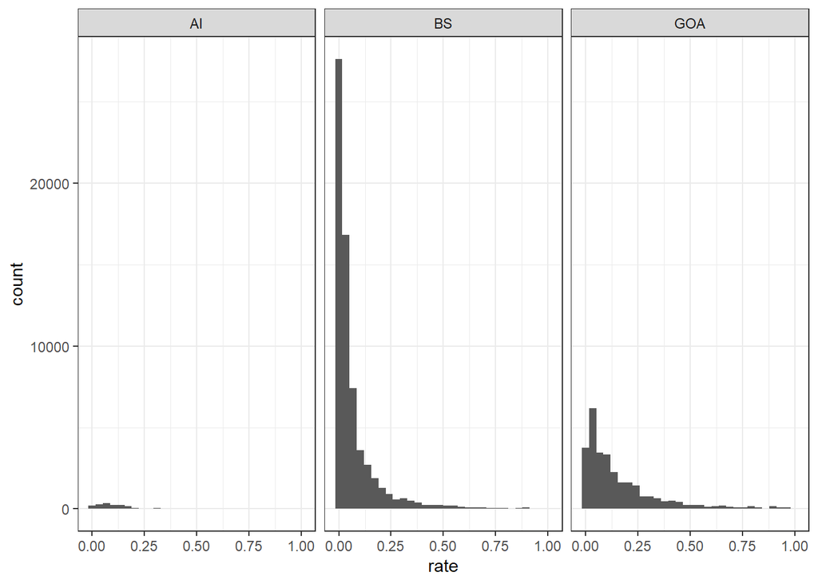

```r
data %>%
  filter(rate>0 & rate<1) %>%
  ggplot(aes(rate)) +
  geom_histogram() +
  facet_wrap(~fmp_area) +
  theme_bw()
```

The official reported PSC statistics from the AK Region are here: https://www.fisheries.noaa.gov/sites/default/files/akro/goasalmonmort2020.html While our numbers don’t match theirs exactly, that’s not totally surprising, because even these official tallies change period (including historical data). Buuuut, we get really close.

We see, for example that

```r
data %>%
  filter(target=="pollock" & fmp_area%in%c("GOA")) %>%
  group_by(year) %>%
  summarise(est_count=sum(pscnq_estimate,na.rm=TRUE),
            spp_count=sum(species_count,na.rm=TRUE)) %>%
  data.frame
```

| year | est_count | spp_count |
| --- | --- | --- |
| 2003 | 4399.894 | 4399.920 |
| 2004 | 13151.969 | 13152.020 |
| 2005 | 27926.821 | 27926.730 |
| 2006 | 15705.544 | 15705.640 |
| 2007 | 35095.662 | 35095.680 |
| 2008 | 10745.604 | 10745.540 |
| 2009 | 3188.348 | 3188.320 |
| 2010 | 44441.852 | 44441.854 |
| 2011 | 12655.026 | 12655.046 |
| 2012 | 16382.670 | 16382.662 |

[output cut: 8 more lines]

If we compare to the published BSAI data we get really close (below) https://www.fisheries.noaa.gov/sites/default/files/akro/chinook_salmon_mortality2020.html

```r
data %>%
  filter(target=="pollock" & fmp_area%in%c("BS","AI")) %>%
  group_by(year) %>%
  summarise(est_count=sum(pscnq_estimate,na.rm=TRUE),
            spp_count=sum(species_count,na.rm=TRUE)) %>%
  data.frame
```

| year | est_count | spp_count |
| --- | --- | --- |
| 2003 | 43095.699 | 43095.740 |
| 2004 | 48796.708 | 51748.460 |
| 2005 | 66251.311 | 68169.150 |
| 2006 | 81015.380 | 82753.210 |
| 2007 | 116575.206 | 122201.280 |
| 2008 | 20666.485 | 21306.670 |
| 2009 | 12131.849 | 12578.870 |
| 2010 | 9848.114 | 9848.085 |
| 2011 | 0.000 | 25499.000 |
| 2012 | 0.000 | 11343.000 |

[output cut: 8 more lines]

Let’s look at the Rockfish Pilot Program.

```r
data %>%
  filter(mgmt_code=="RPP" & nmfsarea%in%c(610,620,630)) %>%
  group_by(year) %>%
  summarise(est_count=sum(pscnq_estimate,na.rm=TRUE),
            spp_count=sum(species_count,na.rm=TRUE)) %>%
  data.frame
```

| year | est_count | spp_count |
| --- | --- | --- |
| 2007 | 509.601 | 509.6200 |
| 2008 | 1688.941 | 1688.9300 |
| 2009 | 860.194 | 860.2000 |
| 2010 | 1246.492 | 1246.4930 |
| 2011 | 699.389 | 699.3891 |
| 2012 | 1238.610 | 1238.6108 |
| 2013 | 2263.589 | 2263.5913 |
| 2014 | 649.180 | 649.1790 |
| 2015 | 1854.967 | 1854.9668 |
| 2016 | 392.711 | 392.7108 |

[output cut: 3 more lines]

```r
con <- dbConnect(odbc::odbc(), "akfin", UID="jwatson", PWD= rstudioapi::askForPassword("Enter AKFIN Password"))

dbFetch(dbSendQuery(con,"select a.haul_date,
a.akr_gear_code,
a.target_fishery_code,
a.pscnq_processing_sector,
a.sample_number,
a.sample_weight,
a.extrapolated_weight,
a.extrapolated_number,
a.ves_akr_cg_num,
a.ves_AKR_length,
a.reporting_area_code
from council.comprehensive_obs a
where a.species_group_code='CHNK'
and a.akr_gear_code in ('PTR','NPT')")) %>%
  rename_all(tolower) %>%
  saveRDS(file="Chinook_extrapolated_weight.RDS")
```